# Machine Learning workshop: tree-based algorithms

Masahiro Ryo @Freie Universitaet Berlin

2019-02-12

## Introduction

This document is made for **Machine Learning workshop at UFZ**.  
Through this workshop, you will be able to learn the basic skills to work with machine learning algorithms.  
We work on regression and classification problems (i.e. supervised learning) today.  
The detailed descriptions about the algorithms introduced today are available in [Ryo & Rillig (2017)](https://esajournals.onlinelibrary.wiley.com/doi/full/10.1002/ecs2.1976)[^1]  
If you have any questions (even small things!), just contact to me (masahiroryo@gmail.com). Yes, I am glad to answer :)

## Table of Contents

1. Settings
   - working directory
   - installing/reading packages
   - reading a dataset
   - setting some functions
2. Decision tree algorithms
   - CART (Breiman’s decision tree[^2])
   - conditional inference tree (Hothorn’s decision tree[^3])
3. Random Forest algorithm & interpretation
   - conditional random forest (Strobl’s random forest[^4])
   - variable importance
   - partial dependence plot

## 1. Settings

Set working directory appropriately.

```r
setwd("C:/Users/masah/Dropbox/i_share/Event & conference/20190212_UFZ/workshop")
getwd()
```

```
## [1] "C:/Users/masah/Dropbox/i_share/Event & conference/20190212_UFZ/workshop"
```

We use a set of R packages. Packages are automatically installed if needed.

```r
package.list = c("party", "mlr","parallelMap", "rpart", "rpart.plot","mmpf")
tmp.install = which(lapply(package.list, require, character.only = TRUE)==FALSE)
if(length(tmp.install)>0) install.packages(package.list[tmp.install], repos = "http://cran.us.r-project.org")
lapply(package.list, require, character.only = TRUE)
```

Let’s read an example dataset:

```r
df = read.csv("data_example.csv")
head(df, 3)
```

```
##         y1 x1 x2 x3       x4   x5 x6       x7        x8        x9 x10
## 1 2.795473  0  0  0      low    A  B 2.059746  6.774423 10.168996   1
## 2 6.366427  1  1  1     high <NA>  C 1.765568 13.000086 11.528108  NA
## 3 2.452364  0  1  1 moderate    B  A 6.870228  8.136200  3.706351  10
##        x11 x12 x13      x14      x15      x16
## 1 1.508253   4   7 8.978635       NA 4.938302
## 2 2.269397   4   7 6.486254 8.459923 2.918157
## 3 7.451168   8   4 7.511756 7.562344 9.600311
```

## 2. Decision tree algorithms

- CART (Breiman’s decision tree)
- conditional inference tree (Hothorn’s decision tree)

### 2.1. CART

CART (classification and regression tree) was proposed by Breiman et al. (1984). Although some decision tree algorithms had already been proposed earlier than their work, their work made tree algorithms useful. The key finding was so-called “pruning” method, which takes the balance between complexity and accuracy.

```r
# creating formula
formula.1 = as.formula(paste("y1", paste(colnames(df)[2:length(colnames(df))], collapse=" + "), sep=" ~ "))
print(formula.1)
```

```
## y1 ~ x1 + x2 + x3 + x4 + x5 + x6 + x7 + x8 + x9 + x10 + x11 +
##     x12 + x13 + x14 + x15 + x16
```

Modeling part. For regression use **method=“anova”**; for classification, use **method=“class”**

```r
# regression
cart.1 = rpart(formula.1, data=df, method="anova",control=rpart.control(minsplit=10, cp=0.001))
```

| **Option** | **Description** |
| --- | --- |
| **method** |  |
| class | method for a classification tree |
| anova | method for a regression tree |
| **control** |  |
| minsplit | minimum number of observations in a node before attempting a split |
| cp | cost complexity factor. a split must decrease the overall lack of fit by a factor of cp before being attempted. |

Note that you can change the two parameters! These parameters are so-called **hyper-parameters** because model *per se* is nonparametric, but the algorithm has the parameters, which can influence results.  
But how? One option is to find the best model using cross validation. Let’s check how cp affects model performance.

Firstly, CART algorithm splits data as much as possible, unless minsplit is met. At the top, x7 at the value of 8.2 was selected to split the dataset into two. Each of the circles (**terminal node**) represents an expected value of the response variable, conditioned by a set of predictors and their threshold values.

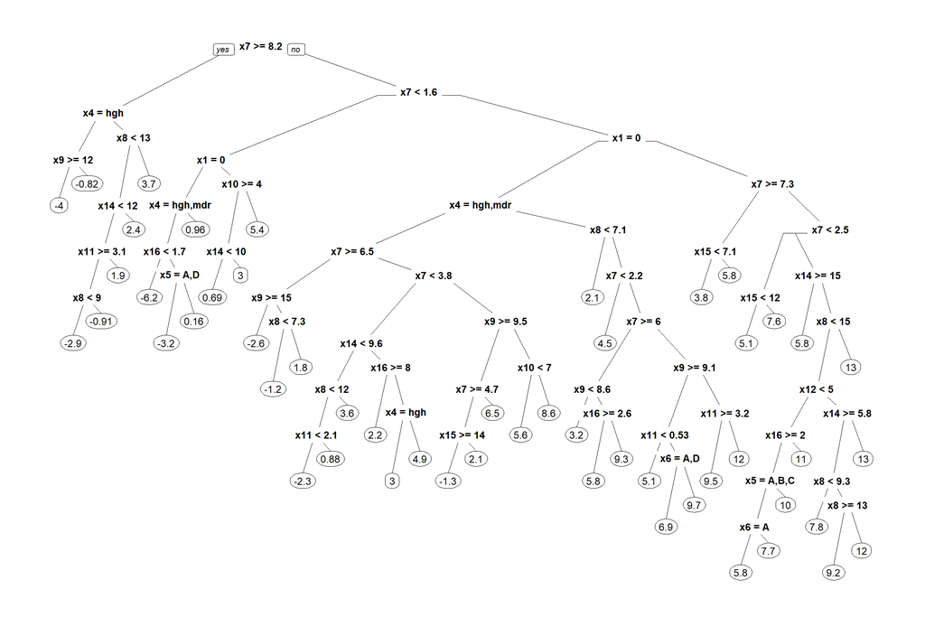

```r
prp(cart.1) # plot with rpart.plot package
```

Yet, the tree is unnecessary complex and overfits to the data. So, we want to simplify the tree structure by pruning (cutting) some (too detailed) brunches, while keeping model performance. Cross-validation is the key to find how much we can prune the tree.

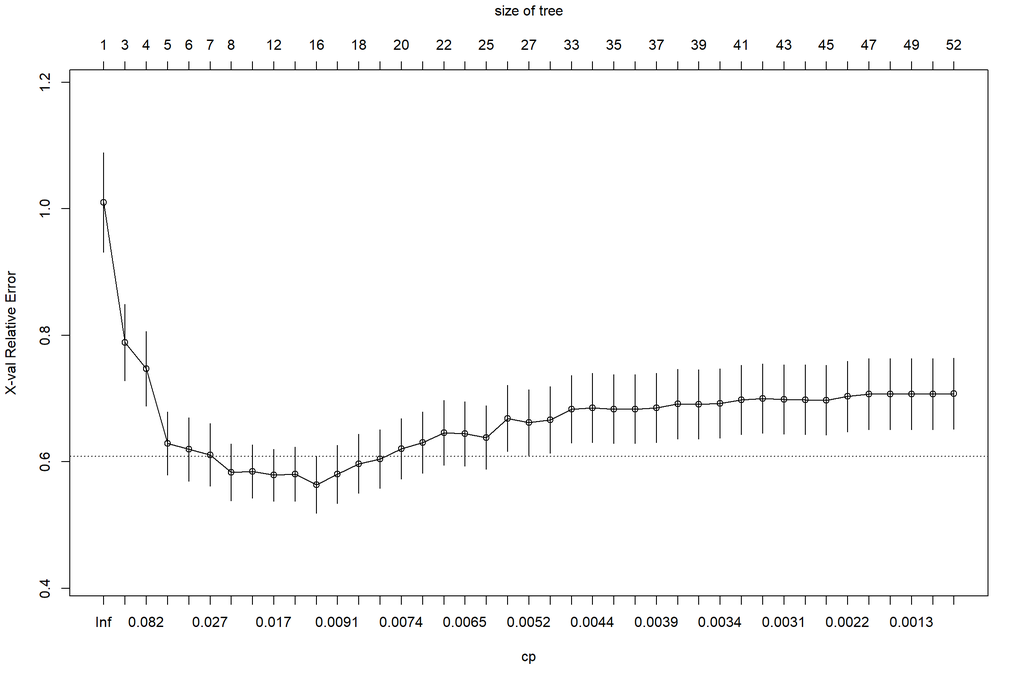

```r
plotcp(cart.1)  #plot cross-validation results
```

[output not shown]

[output cut: 39 more lines]

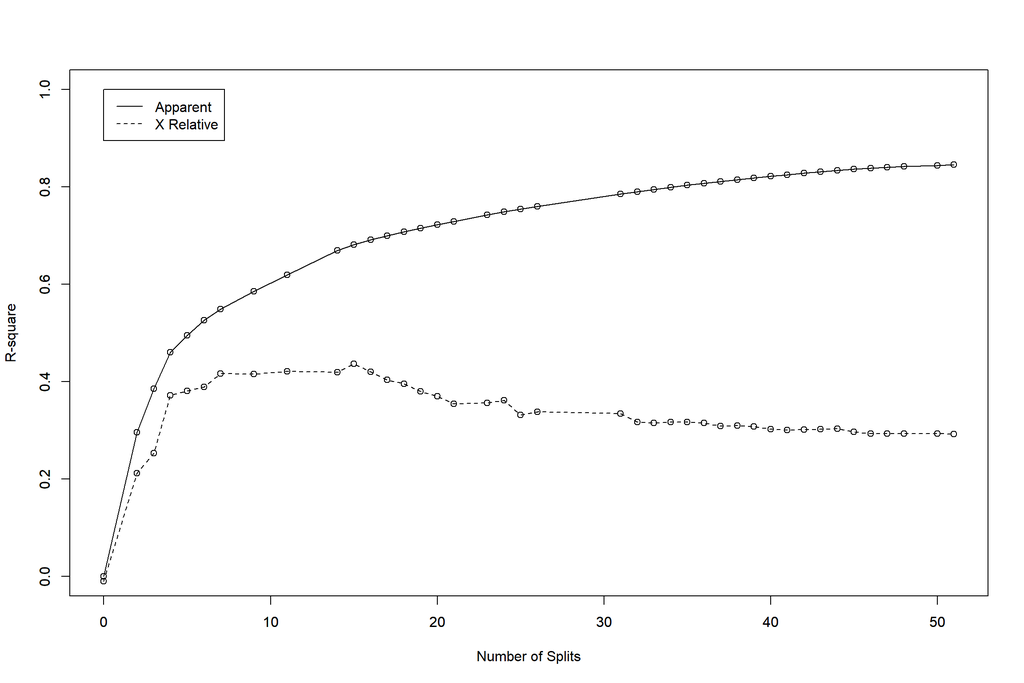

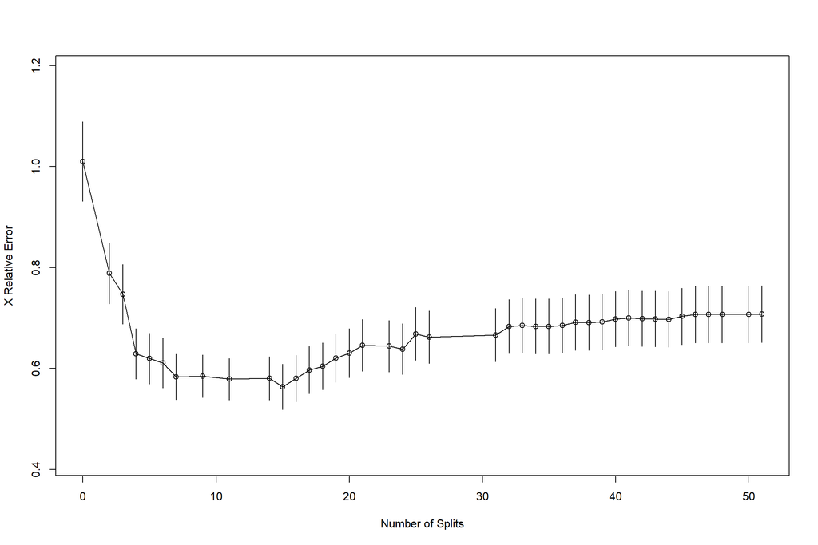

```r
rsq.rpart(cart.1)   #plot approximate R-squared and relative error for different splits (2 plots). labels are only appropriate for the "anova" method.
```

```r
cp.best = cart.1$cptable[which(cart.1$cptable[,"xerror"]==min(cart.1$cptable[,"xerror"])),"CP"]
```

Now, we found **cp=0.0098657** the best for balancing complexity and accuracy (note that the performance even improved by reducing overfitting!). Let’s compare the best and original tree structures.

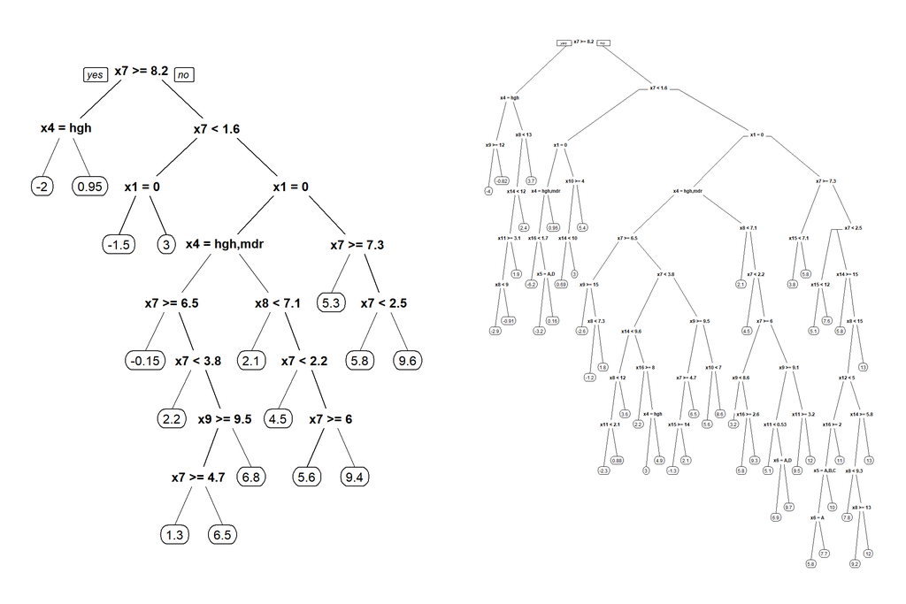

```r
# regression (y1) and classification (y2)
cart.1.best = rpart(formula.1, data=df, method="anova",control=rpart.control(minsplit=10, cp=cp.best))

par(mfrow=c(1,2))
prp(cart.1.best)
prp(cart.1)
```

You can also play with changing minsplit. This is another hyperparameter.

### 2.2. Conditional inference tree

Conditional inference tree is another tree-based algorithm developed relatively recently by Hothorn et al. (2006). They found that, if the data must be split more or not can be determined based on statistical significance, and by doing so the structure of a tree can be much simplified while the performance does not significantly reduce from the model selected based on CART CV-technique.  
We use **party** package:

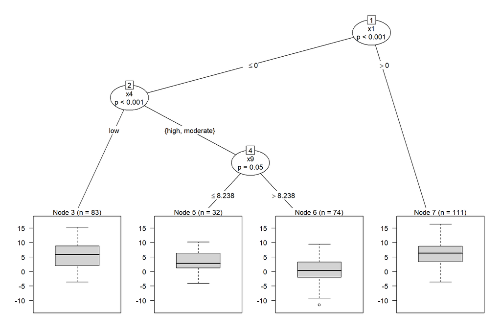

```r
ctree.1 = ctree(formula.1, df, control = ctree_control(testtype = "Bonferroni", mincriterion = 0.95, minsplit = 10, minbucket = 7))
plot(ctree.1)
```

If testtype is “Univariate”, p-value correction is not peformed, so more predictors can appear. If implementing correction or not is always difficult, as it is a trade-off of Type 1 & 2 error.

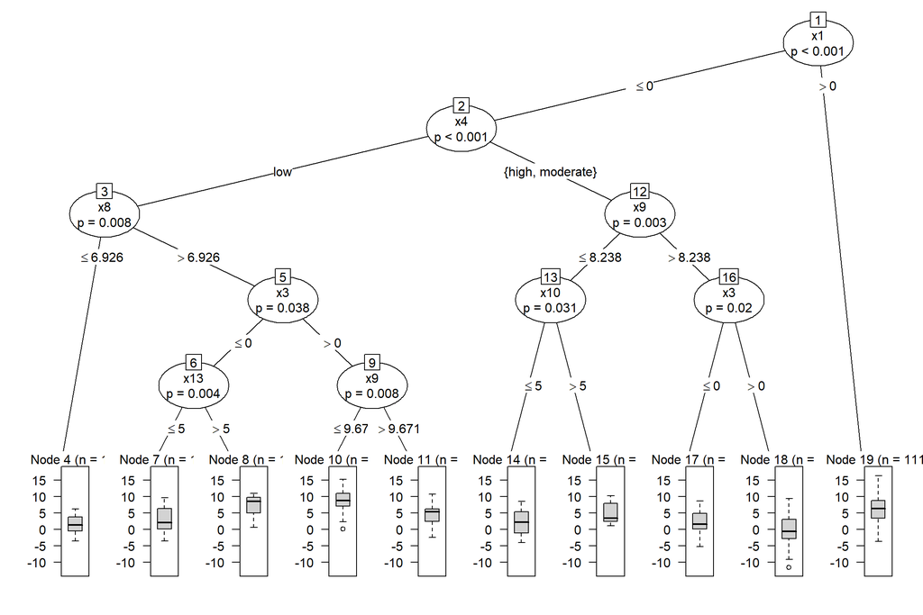

```r
ctree.2 = ctree(formula.1, df, control = ctree_control(testtype = "Univariate", mincriterion = 0.95, minsplit = 10, minbucket = 7))
plot(ctree.2)
```

## 3. Random Forest algorithm & interpretation

#### In this seciton, we learn a random forest algorithm based on conditional inference tree.

The RF algorithm based on conditional inference tree is developed in the package **party**. While we can use the package, let’s learn another useful package, **mlr**, which is an integrative tool for machine learning algorithms.  
In this section, we learn the followings:

- modeling with RF
- parameter tuning
- interpretation: variable importance
- visualization: partial dependence (PD) plot and individual conditional expectation (ICE) plot

**mlr** can allow parallel computing. The number is the number of cores used.

```r
parallelStartSocket(3)
```

```
## Starting parallelization in mode=socket with cpus=3.
```

#### Model set up

```r
regr.task = makeRegrTask(data = df, target = "y1")
regr.learner.cforest = makeLearner(cl="regr.cforest", predict.type = "response")
model.cforest = train(regr.learner.cforest, regr.task)
```

Model performance can be evaluated using various indicators.

```r
pred.cforest = predict(model.cforest, task = regr.task)
listMeasures(regr.task)
```

```
##  [1] "featperc"    "mae"         "mape"        "medse"       "msle"
##  [6] "rae"         "spearmanrho" "timeboth"    "timetrain"   "rmsle"
## [11] "timepredict" "medae"       "sse"         "expvar"      "kendalltau"
## [16] "rmse"        "mse"         "rrse"        "sae"         "rsq"
## [21] "arsq"
```

```r
performance(pred.cforest, measures = list(mse, rsq))
```

```
##        mse        rsq
## 11.2242302  0.5102861
```

#### Cross validation

We can see the reduction of the performance from the model fitting. **aggr** shows the averages from the independent k-fold tests (**measures.test**).

```r
cv.cforest$aggr
```

```
## mse.test.mean rsq.test.mean
##    17.2855779     0.2399196
```

```r
cv.cforest$measures.test
```

```
##   iter      mse       rsq
## 1    1 16.74682 0.1669095
## 2    2 17.57950 0.2756194
## 3    3 17.53042 0.2772299
```

Let’s keep the best model.

```r
model.cforest.best = train(setHyperPars(makeLearner("regr.cforest"), par.vals = tune.cforest$x),regr.task)
```

We can visualize how these hyper-parameters affect to model performance. Ideally, the larger mtry and ntree, the lower error, in this example.

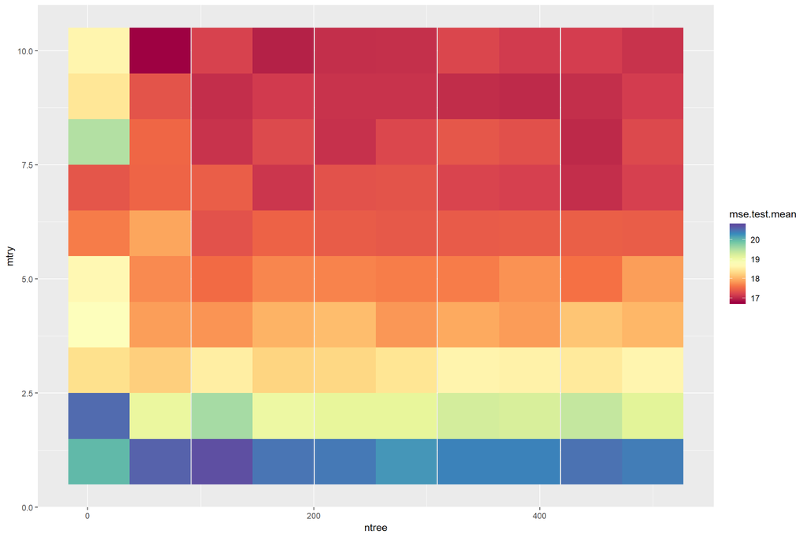

```r
plotHyperParsEffect(generateHyperParsEffectData(tune.cforest), x = "ntree", y = "mtry", z = "mse.test.mean",
  plot.type = "heatmap")
```

#### Variable importance measure

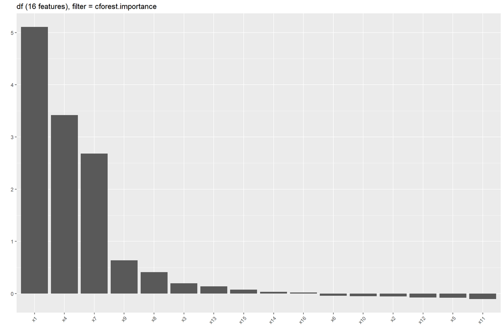

```r
vimp = generateFilterValuesData(regr.task, method = "cforest.importance")
plotFilterValues(vimp)
```

We realize that only a few variables are important (x1,x4,x7…). It is worth trying **variable selection**, removing noisy variables to improve the model performance. Let’s say, we use only the top 5 important variables in RF modeling.

```r
lrn = makeFilterWrapper(learner = "regr.cforest",
  fw.method = "cforest.importance", fw.abs = 5)
r = resample(learner = lrn, task = regr.task, resampling = rdesc, show.info = FALSE, models = TRUE)
```

```
## Exporting objects to slaves for mode socket: .mlr.slave.options
```

```
## Mapping in parallel: mode = socket; cpus = 3; elements = 3.
```

```r
r$aggr
```

```
## mse.test.mean
##      15.96461
```

#### Partial dependence (PD) plot and Individual Conditional Expectation (ICE) plot

Both plot tools are useful when we want to understand the inside of the RF model. These tools can visualize how a particular variable was used to predict the response variable:

```r
pd = generatePartialDependenceData(model.cforest.best, regr.task, "x9", individual = F)
```

```
## Mapping in parallel: mode = socket; cpus = 3; elements = 1.
```

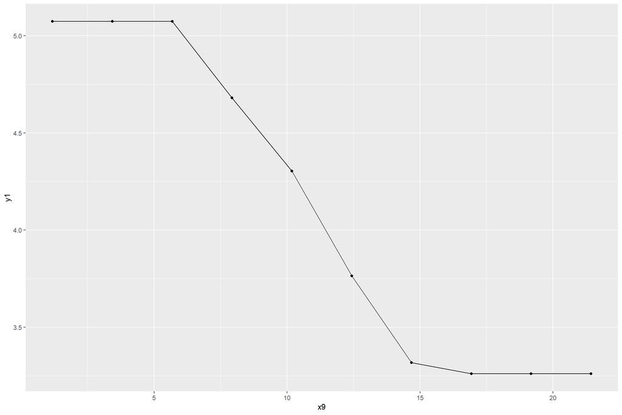

```r
plotPartialDependence(pd)
```

Note that if we want to plot all variables, we do not specify it.

```r
pd.all = generatePartialDependenceData(model.cforest.best, regr.task, individual = F)
```

```
## Mapping in parallel: mode = socket; cpus = 3; elements = 16.
```

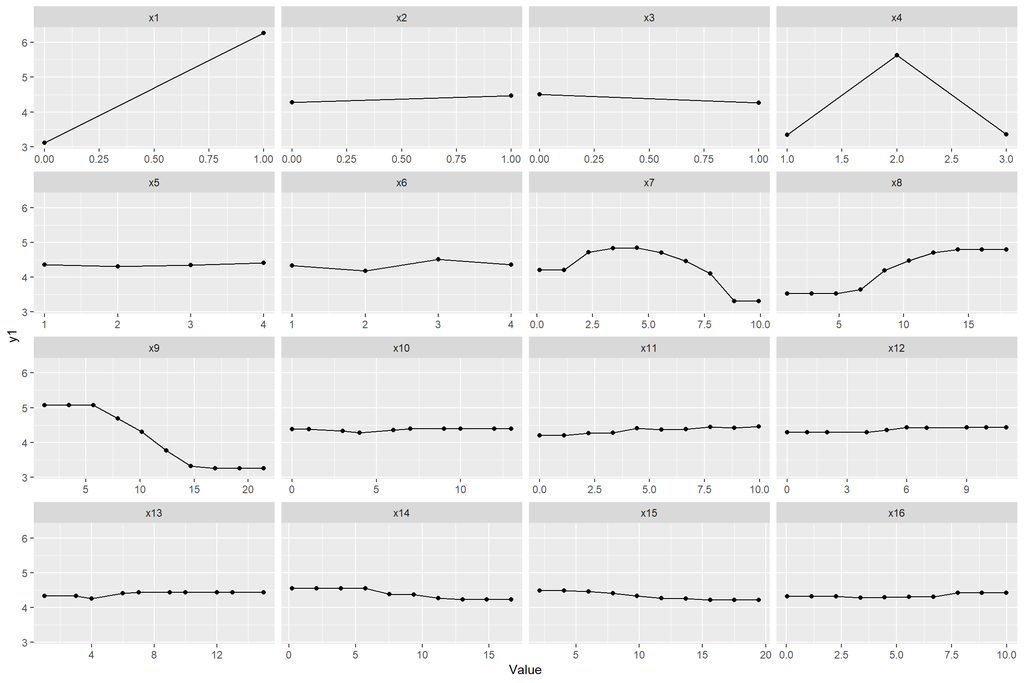

```r
plotPartialDependence(pd.all)
```

PD plot is the overall avarage taken from ICE plot. ICE plot is useful particularly when we look for interaction. If we find some patterns of lines, we can expect the predictor interacts with another predictor.

```r
ice = generatePartialDependenceData(model.cforest.best, regr.task, "x9", individual = T)
```

```
## Mapping in parallel: mode = socket; cpus = 3; elements = 1.
```

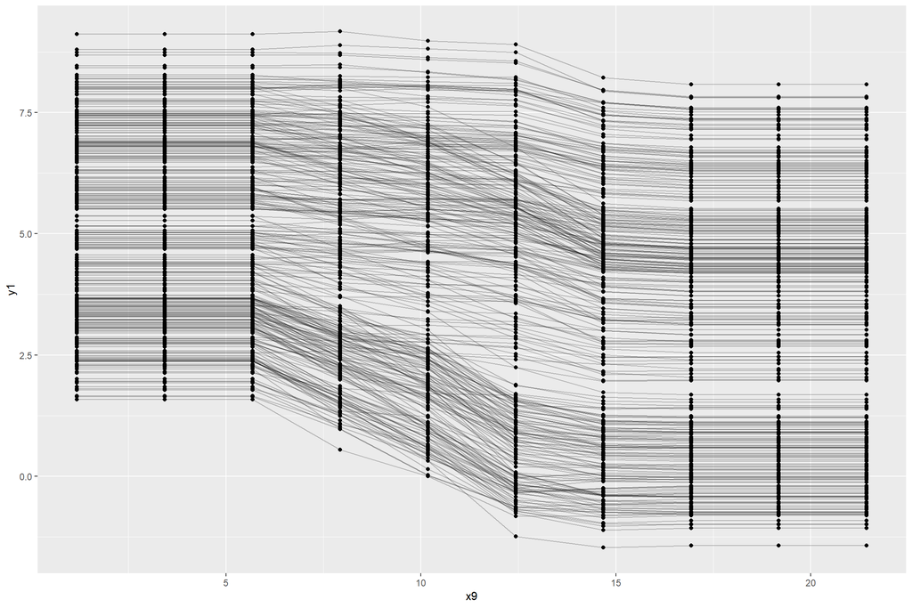

```r
plotPartialDependence(ice)
```

```r
ice.all = generatePartialDependenceData(model.cforest.best, regr.task, individual = T)
```

```
## Mapping in parallel: mode = socket; cpus = 3; elements = 16.
```

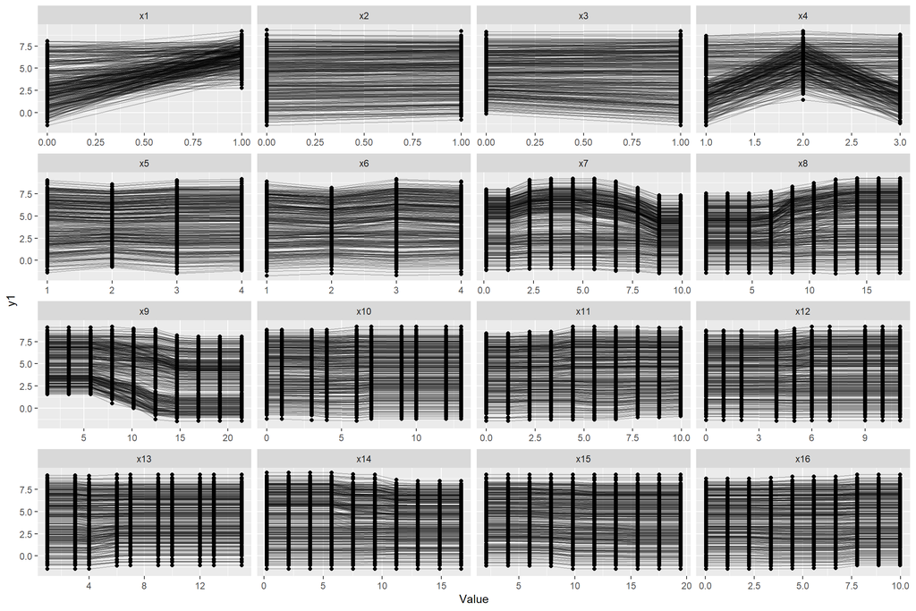

```r
plotPartialDependence(ice.all)
```

```r
parallelStop()
```

```
## Stopped parallelization. All cleaned up.
```

##### That’s all for today :)

## References

[^1]: Ryo, M. and Rillig, M.C. (2017) Statistically reinforced machine learning for nonlinear patterns and variable interactions. [Ecosphere](https://esajournals.onlinelibrary.wiley.com/doi/full/10.1002/ecs2.1976)
[^2]: Breiman, L. et al. (1984) Classification and regression trees, Chapman and Hall/CRC.
[^3]: Hothorn, T. et al. (2006) Unbiased recursive partitioning : A conditional inference framework. J. Comput. Graph. Stat.
[^4]: Strobl, C. et al. (2008) Conditional variable importance for random forests. BMC Bioinformatics.